# Risk Factor Analysis

## Outcome Variable

**Outcome Variable:** stunted

## Predictor Variables

**Intervention Variable:** hfoodsec

**Adjustment Set:**

unadjusted

## Stratifying Variables

The analysis was stratified on these variable(s):

- agecat
- studyid
- country

## Data Summary

| agecat | studyid | country | hfoodsec | stunted | n_cell | n |
| --- | --- | --- | --- | --- | --- | --- |
| Birth | ki0047075b-MAL-ED | BANGLADESH | Food Secure | 0 | 121 | 172 |
| Birth | ki0047075b-MAL-ED | BANGLADESH | Food Secure | 1 | 23 | 172 |
| Birth | ki0047075b-MAL-ED | BANGLADESH | Mildly Food Insecure | 0 | 3 | 172 |
| Birth | ki0047075b-MAL-ED | BANGLADESH | Mildly Food Insecure | 1 | 1 | 172 |
| Birth | ki0047075b-MAL-ED | BANGLADESH | Food Insecure | 0 | 19 | 172 |
| Birth | ki0047075b-MAL-ED | BANGLADESH | Food Insecure | 1 | 5 | 172 |
| Birth | ki0047075b-MAL-ED | BRAZIL | Food Secure | 0 | 0 | 28 |
| Birth | ki0047075b-MAL-ED | BRAZIL | Food Secure | 1 | 0 | 28 |
| Birth | ki0047075b-MAL-ED | BRAZIL | Mildly Food Insecure | 0 | 3 | 28 |
| Birth | ki0047075b-MAL-ED | BRAZIL | Mildly Food Insecure | 1 | 1 | 28 |
| Birth | ki0047075b-MAL-ED | BRAZIL | Food Insecure | 0 | 20 | 28 |
| Birth | ki0047075b-MAL-ED | BRAZIL | Food Insecure | 1 | 4 | 28 |
| Birth | ki0047075b-MAL-ED | INDIA | Food Secure | 0 | 28 | 37 |
| Birth | ki0047075b-MAL-ED | INDIA | Food Secure | 1 | 6 | 37 |
| Birth | ki0047075b-MAL-ED | INDIA | Mildly Food Insecure | 0 | 1 | 37 |
| Birth | ki0047075b-MAL-ED | INDIA | Mildly Food Insecure | 1 | 0 | 37 |
| Birth | ki0047075b-MAL-ED | INDIA | Food Insecure | 0 | 1 | 37 |
| Birth | ki0047075b-MAL-ED | INDIA | Food Insecure | 1 | 1 | 37 |
| Birth | ki0047075b-MAL-ED | NEPAL | Food Secure | 0 | 10 | 14 |
| Birth | ki0047075b-MAL-ED | NEPAL | Food Secure | 1 | 0 | 14 |
| Birth | ki0047075b-MAL-ED | NEPAL | Mildly Food Insecure | 0 | 1 | 14 |
| Birth | ki0047075b-MAL-ED | NEPAL | Mildly Food Insecure | 1 | 0 | 14 |
| Birth | ki0047075b-MAL-ED | NEPAL | Food Insecure | 0 | 3 | 14 |
| Birth | ki0047075b-MAL-ED | NEPAL | Food Insecure | 1 | 0 | 14 |
| Birth | ki0047075b-MAL-ED | PERU | Food Secure | 0 | 20 | 91 |
| Birth | ki0047075b-MAL-ED | PERU | Food Secure | 1 | 4 | 91 |
| Birth | ki0047075b-MAL-ED | PERU | Mildly Food Insecure | 0 | 21 | 91 |
| Birth | ki0047075b-MAL-ED | PERU | Mildly Food Insecure | 1 | 2 | 91 |
| Birth | ki0047075b-MAL-ED | PERU | Food Insecure | 0 | 39 | 91 |
| Birth | ki0047075b-MAL-ED | PERU | Food Insecure | 1 | 5 | 91 |

[output cut: 168 more lines]

The following strata were considered:

- agecat: 24 months, studyid: ki0047075b-MAL-ED, country: BANGLADESH
- agecat: 24 months, studyid: ki0047075b-MAL-ED, country: BRAZIL
- agecat: 24 months, studyid: ki0047075b-MAL-ED, country: INDIA
- agecat: 24 months, studyid: ki0047075b-MAL-ED, country: NEPAL
- agecat: 24 months, studyid: ki0047075b-MAL-ED, country: PERU
- agecat: 24 months, studyid: ki0047075b-MAL-ED, country: SOUTH AFRICA
- agecat: 24 months, studyid: ki1017093-NIH-Birth, country: BANGLADESH
- agecat: 24 months, studyid: ki1017093c-NIH-Crypto, country: BANGLADESH
- agecat: 24 months, studyid: ki1113344-GMS-Nepal, country: NEPAL
- agecat: 24 months, studyid: kiGH5241-JiVitA-3, country: BANGLADESH
- agecat: 24 months, studyid: kiGH5241-JiVitA-4, country: BANGLADESH
- agecat: 6 months, studyid: ki0047075b-MAL-ED, country: BANGLADESH
- agecat: 6 months, studyid: ki0047075b-MAL-ED, country: BRAZIL
- agecat: 6 months, studyid: ki0047075b-MAL-ED, country: INDIA
- agecat: 6 months, studyid: ki0047075b-MAL-ED, country: NEPAL
- agecat: 6 months, studyid: ki0047075b-MAL-ED, country: PERU
- agecat: 6 months, studyid: ki0047075b-MAL-ED, country: SOUTH AFRICA
- agecat: 6 months, studyid: ki1017093-NIH-Birth, country: BANGLADESH
- agecat: 6 months, studyid: ki1017093c-NIH-Crypto, country: BANGLADESH
- agecat: 6 months, studyid: ki1113344-GMS-Nepal, country: NEPAL
- agecat: 6 months, studyid: kiGH5241-JiVitA-3, country: BANGLADESH
- agecat: 6 months, studyid: kiGH5241-JiVitA-4, country: BANGLADESH
- agecat: Birth, studyid: ki0047075b-MAL-ED, country: BANGLADESH
- agecat: Birth, studyid: ki0047075b-MAL-ED, country: BRAZIL
- agecat: Birth, studyid: ki0047075b-MAL-ED, country: INDIA
- agecat: Birth, studyid: ki0047075b-MAL-ED, country: NEPAL
- agecat: Birth, studyid: ki0047075b-MAL-ED, country: PERU
- agecat: Birth, studyid: ki0047075b-MAL-ED, country: SOUTH AFRICA
- agecat: Birth, studyid: ki1017093-NIH-Birth, country: BANGLADESH
- agecat: Birth, studyid: ki1017093c-NIH-Crypto, country: BANGLADESH
- agecat: Birth, studyid: ki1113344-GMS-Nepal, country: NEPAL
- agecat: Birth, studyid: kiGH5241-JiVitA-3, country: BANGLADESH
- agecat: Birth, studyid: kiGH5241-JiVitA-4, country: BANGLADESH

### Dropped Strata

Some strata were dropped due to rare outcomes:

- agecat: Birth, studyid: ki0047075b-MAL-ED, country: BANGLADESH
- agecat: Birth, studyid: ki0047075b-MAL-ED, country: BRAZIL
- agecat: Birth, studyid: ki0047075b-MAL-ED, country: INDIA
- agecat: Birth, studyid: ki0047075b-MAL-ED, country: NEPAL
- agecat: Birth, studyid: ki0047075b-MAL-ED, country: PERU
- agecat: Birth, studyid: ki0047075b-MAL-ED, country: SOUTH AFRICA
- agecat: 6 months, studyid: ki0047075b-MAL-ED, country: BANGLADESH
- agecat: 6 months, studyid: ki0047075b-MAL-ED, country: BRAZIL
- agecat: 6 months, studyid: ki0047075b-MAL-ED, country: INDIA
- agecat: 6 months, studyid: ki0047075b-MAL-ED, country: NEPAL
- agecat: 6 months, studyid: ki0047075b-MAL-ED, country: SOUTH AFRICA
- agecat: 24 months, studyid: ki0047075b-MAL-ED, country: BANGLADESH
- agecat: 24 months, studyid: ki0047075b-MAL-ED, country: BRAZIL
- agecat: 24 months, studyid: ki0047075b-MAL-ED, country: INDIA
- agecat: 24 months, studyid: ki0047075b-MAL-ED, country: NEPAL

## Methods Detail

We’re interested in the causal parameters $E[Y_a]$ for all values of $a \in \mathcal{A}$. These parameters represent the mean outcome if, possibly contrary to fact, we intervened to set all units to have $A=a$. Under the randomization and positivity assumptions, these are identified by the statistical parameters $\psi_a=E_W[E_{Y|A,W}(Y|A=a,W)]$. In addition, we’re interested in the mean of $Y$, $E[Y]$ under no intervention (the observed mean). We will estimate these parameters by using SuperLearner to fit the relevant likelihood factors – $E_{Y|A,W}(Y|A=a,W)$ and $p(A=a|W)$, and then updating our likelihood fit using a joint TMLE.

For unadjusted analyses ($W=\{\}$), initial likelihoods were estimated using Lrnr_glm to estimate the simple $E(Y|A)$ and Lrnr_mean to estimate $p(A)$. For adjusted analyses, a small library containing Lrnr_glmnet, Lrnr_xgboost, and Lrnr_mean was used.

Having estimated these parameters, we will then use the delta method to estimate relative risks and attributable risks relative to a prespecified baseline level of $A$.

# Results Detail

## Results Plots

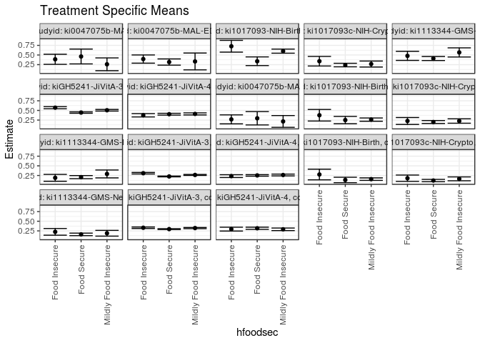

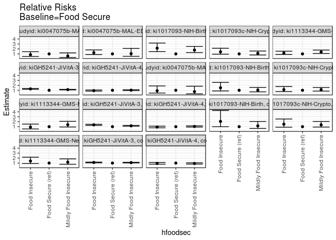

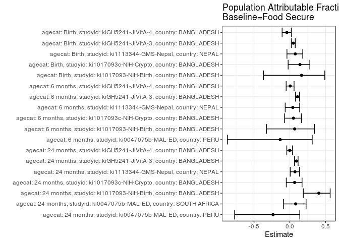

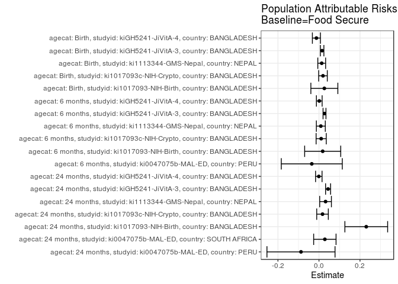

## Results Table

### Parameter: TSM

| agecat | studyid | country | intervention_level | baseline_level | estimate | ci_lower | ci_upper |
| --- | --- | --- | --- | --- | --- | --- | --- |
| Birth | ki1017093-NIH-Birth | BANGLADESH | Food Secure | NA | 0.1333333 | 0.0630456 | 0.2036211 |
| Birth | ki1017093-NIH-Birth | BANGLADESH | Mildly Food Insecure | NA | 0.1548117 | 0.1223576 | 0.1872659 |
| Birth | ki1017093-NIH-Birth | BANGLADESH | Food Insecure | NA | 0.2750000 | 0.1365124 | 0.4134876 |
| Birth | ki1017093c-NIH-Crypto | BANGLADESH | Food Secure | NA | 0.1184510 | 0.0882024 | 0.1486996 |
| Birth | ki1017093c-NIH-Crypto | BANGLADESH | Mildly Food Insecure | NA | 0.1626794 | 0.1126087 | 0.2127502 |
| Birth | ki1017093c-NIH-Crypto | BANGLADESH | Food Insecure | NA | 0.1785714 | 0.0966125 | 0.2605303 |
| Birth | ki1113344-GMS-Nepal | NEPAL | Food Secure | NA | 0.1593291 | 0.1264612 | 0.1921971 |
| Birth | ki1113344-GMS-Nepal | NEPAL | Mildly Food Insecure | NA | 0.1886792 | 0.1141414 | 0.2632171 |
| Birth | ki1113344-GMS-Nepal | NEPAL | Food Insecure | NA | 0.2247191 | 0.1379378 | 0.3115004 |
| Birth | kiGH5241-JiVitA-3 | BANGLADESH | Food Secure | NA | 0.2959286 | 0.2841073 | 0.3077500 |
| Birth | kiGH5241-JiVitA-3 | BANGLADESH | Mildly Food Insecure | NA | 0.3227394 | 0.3082102 | 0.3372685 |
| Birth | kiGH5241-JiVitA-3 | BANGLADESH | Food Insecure | NA | 0.3312303 | 0.3119804 | 0.3504801 |
| Birth | kiGH5241-JiVitA-4 | BANGLADESH | Food Secure | NA | 0.3175157 | 0.2894515 | 0.3455799 |
| Birth | kiGH5241-JiVitA-4 | BANGLADESH | Mildly Food Insecure | NA | 0.2907662 | 0.2572709 | 0.3242615 |
| Birth | kiGH5241-JiVitA-4 | BANGLADESH | Food Insecure | NA | 0.2952646 | 0.2454466 | 0.3450827 |
| 6 months | ki0047075b-MAL-ED | PERU | Food Secure | NA | 0.2962963 | 0.1232791 | 0.4693135 |
| 6 months | ki0047075b-MAL-ED | PERU | Mildly Food Insecure | NA | 0.2142857 | 0.0616124 | 0.3669590 |
| 6 months | ki0047075b-MAL-ED | PERU | Food Insecure | NA | 0.2678571 | 0.1513457 | 0.3843686 |
| 6 months | ki1017093-NIH-Birth | BANGLADESH | Food Secure | NA | 0.2500000 | 0.1550252 | 0.3449748 |
| 6 months | ki1017093-NIH-Birth | BANGLADESH | Mildly Food Insecure | NA | 0.2613909 | 0.2191787 | 0.3036030 |
| 6 months | ki1017093-NIH-Birth | BANGLADESH | Food Insecure | NA | 0.3750000 | 0.2248316 | 0.5251684 |
| 6 months | ki1017093c-NIH-Crypto | BANGLADESH | Food Secure | NA | 0.1990632 | 0.1611638 | 0.2369627 |
| 6 months | ki1017093c-NIH-Crypto | BANGLADESH | Mildly Food Insecure | NA | 0.2254902 | 0.1681031 | 0.2828773 |
| 6 months | ki1017093c-NIH-Crypto | BANGLADESH | Food Insecure | NA | 0.2261905 | 0.1366609 | 0.3157201 |
| 6 months | ki1113344-GMS-Nepal | NEPAL | Food Secure | NA | 0.2070707 | 0.1671245 | 0.2470169 |
| 6 months | ki1113344-GMS-Nepal | NEPAL | Mildly Food Insecure | NA | 0.2894737 | 0.1874188 | 0.3915286 |
| 6 months | ki1113344-GMS-Nepal | NEPAL | Food Insecure | NA | 0.1891892 | 0.0998713 | 0.2785070 |
| 6 months | kiGH5241-JiVitA-3 | BANGLADESH | Food Secure | NA | 0.2244801 | 0.2142903 | 0.2346699 |
| 6 months | kiGH5241-JiVitA-3 | BANGLADESH | Mildly Food Insecure | NA | 0.2636558 | 0.2510168 | 0.2762948 |
| 6 months | kiGH5241-JiVitA-3 | BANGLADESH | Food Insecure | NA | 0.3085797 | 0.2887924 | 0.3283670 |
| 6 months | kiGH5241-JiVitA-4 | BANGLADESH | Food Secure | NA | 0.2514333 | 0.2316127 | 0.2712538 |
| 6 months | kiGH5241-JiVitA-4 | BANGLADESH | Mildly Food Insecure | NA | 0.2620012 | 0.2382410 | 0.2857613 |
| 6 months | kiGH5241-JiVitA-4 | BANGLADESH | Food Insecure | NA | 0.2331190 | 0.1966330 | 0.2696049 |
| 24 months | ki0047075b-MAL-ED | PERU | Food Secure | NA | 0.4615385 | 0.2690159 | 0.6540610 |
| 24 months | ki0047075b-MAL-ED | PERU | Mildly Food Insecure | NA | 0.2592593 | 0.0931838 | 0.4253347 |
| 24 months | ki0047075b-MAL-ED | PERU | Food Insecure | NA | 0.3888889 | 0.2582528 | 0.5195249 |
| 24 months | ki0047075b-MAL-ED | SOUTH AFRICA | Food Secure | NA | 0.3178295 | 0.2373006 | 0.3983583 |
| 24 months | ki0047075b-MAL-ED | SOUTH AFRICA | Mildly Food Insecure | NA | 0.3333333 | 0.1150804 | 0.5515863 |
| 24 months | ki0047075b-MAL-ED | SOUTH AFRICA | Food Insecure | NA | 0.3950617 | 0.2883657 | 0.5017577 |
| 24 months | ki1017093-NIH-Birth | BANGLADESH | Food Secure | NA | 0.3382353 | 0.2256552 | 0.4508154 |
| 24 months | ki1017093-NIH-Birth | BANGLADESH | Mildly Food Insecure | NA | 0.6006098 | 0.5475442 | 0.6536753 |
| 24 months | ki1017093-NIH-Birth | BANGLADESH | Food Insecure | NA | 0.7272727 | 0.5751441 | 0.8794013 |
| 24 months | ki1017093c-NIH-Crypto | BANGLADESH | Food Secure | NA | 0.2395210 | 0.1937054 | 0.2853365 |
| 24 months | ki1017093c-NIH-Crypto | BANGLADESH | Mildly Food Insecure | NA | 0.2661290 | 0.1882687 | 0.3439893 |
| 24 months | ki1017093c-NIH-Crypto | BANGLADESH | Food Insecure | NA | 0.3392857 | 0.2151586 | 0.4634128 |
| 24 months | ki1113344-GMS-Nepal | NEPAL | Food Secure | NA | 0.4093567 | 0.3571888 | 0.4615246 |
| 24 months | ki1113344-GMS-Nepal | NEPAL | Mildly Food Insecure | NA | 0.5671642 | 0.4484011 | 0.6859273 |
| 24 months | ki1113344-GMS-Nepal | NEPAL | Food Insecure | NA | 0.4782609 | 0.3602730 | 0.5962488 |
| 24 months | kiGH5241-JiVitA-3 | BANGLADESH | Food Secure | NA | 0.4446452 | 0.4264007 | 0.4628896 |
| 24 months | kiGH5241-JiVitA-3 | BANGLADESH | Mildly Food Insecure | NA | 0.5045273 | 0.4834543 | 0.5256004 |
| 24 months | kiGH5241-JiVitA-3 | BANGLADESH | Food Insecure | NA | 0.5709759 | 0.5435392 | 0.5984126 |
| 24 months | kiGH5241-JiVitA-4 | BANGLADESH | Food Secure | NA | 0.4018341 | 0.3782749 | 0.4253933 |
| 24 months | kiGH5241-JiVitA-4 | BANGLADESH | Mildly Food Insecure | NA | 0.4093842 | 0.3824239 | 0.4363445 |
| 24 months | kiGH5241-JiVitA-4 | BANGLADESH | Food Insecure | NA | 0.3743842 | 0.3313064 | 0.4174621 |

### Parameter: E(Y)

| agecat | studyid | country | intervention_level | baseline_level | estimate | ci_lower | ci_upper |
| --- | --- | --- | --- | --- | --- | --- | --- |
| Birth | ki1017093-NIH-Birth | BANGLADESH | NA | NA | 0.1595395 | 0.1304091 | 0.1886699 |
| Birth | ki1017093c-NIH-Crypto | BANGLADESH | NA | NA | 0.1379781 | 0.1129774 | 0.1629789 |
| Birth | ki1113344-GMS-Nepal | NEPAL | NA | NA | 0.1726190 | 0.1440245 | 0.2012136 |
| Birth | kiGH5241-JiVitA-3 | BANGLADESH | NA | NA | 0.3112643 | 0.3026111 | 0.3199174 |
| Birth | kiGH5241-JiVitA-4 | BANGLADESH | NA | NA | 0.3049822 | 0.2848489 | 0.3251155 |
| 6 months | ki0047075b-MAL-ED | PERU | NA | NA | 0.2612613 | 0.1791629 | 0.3433597 |
| 6 months | ki1017093-NIH-Birth | BANGLADESH | NA | NA | 0.2681564 | 0.2306532 | 0.3056597 |
| 6 months | ki1017093c-NIH-Crypto | BANGLADESH | NA | NA | 0.2097902 | 0.1799252 | 0.2396552 |
| 6 months | ki1113344-GMS-Nepal | NEPAL | NA | NA | 0.2161172 | 0.1815615 | 0.2506729 |
| 6 months | kiGH5241-JiVitA-3 | BANGLADESH | NA | NA | 0.2514442 | 0.2432971 | 0.2595914 |
| 6 months | kiGH5241-JiVitA-4 | BANGLADESH | NA | NA | 0.2528688 | 0.2386164 | 0.2671211 |
| 24 months | ki0047075b-MAL-ED | PERU | NA | NA | 0.3738318 | 0.2817277 | 0.4659358 |
| 24 months | ki0047075b-MAL-ED | SOUTH AFRICA | NA | NA | 0.3464912 | 0.2845889 | 0.4083936 |
| 24 months | ki1017093-NIH-Birth | BANGLADESH | NA | NA | 0.5687646 | 0.5218455 | 0.6156837 |
| 24 months | ki1017093c-NIH-Crypto | BANGLADESH | NA | NA | 0.2568093 | 0.2190047 | 0.2946140 |
| 24 months | ki1113344-GMS-Nepal | NEPAL | NA | NA | 0.4414226 | 0.3968613 | 0.4859839 |
| 24 months | kiGH5241-JiVitA-3 | BANGLADESH | NA | NA | 0.4890431 | 0.4756182 | 0.5024680 |
| 24 months | kiGH5241-JiVitA-4 | BANGLADESH | NA | NA | 0.4010185 | 0.3840244 | 0.4180125 |

### Parameter: RR

| agecat | studyid | country | intervention_level | baseline_level | estimate | ci_lower | ci_upper |
| --- | --- | --- | --- | --- | --- | --- | --- |
| Birth | ki1017093-NIH-Birth | BANGLADESH | Food Secure | Food Secure | 1.0000000 | 1.0000000 | 1.000000 |
| Birth | ki1017093-NIH-Birth | BANGLADESH | Mildly Food Insecure | Food Secure | 1.1610879 | 0.6583920 | 2.047602 |
| Birth | ki1017093-NIH-Birth | BANGLADESH | Food Insecure | Food Secure | 2.0625000 | 0.9948915 | 4.275749 |
| Birth | ki1017093c-NIH-Crypto | BANGLADESH | Food Secure | Food Secure | 1.0000000 | 1.0000000 | 1.000000 |
| Birth | ki1017093c-NIH-Crypto | BANGLADESH | Mildly Food Insecure | Food Secure | 1.3733898 | 0.9206727 | 2.048719 |
| Birth | ki1017093c-NIH-Crypto | BANGLADESH | Food Insecure | Food Secure | 1.5075549 | 0.8915974 | 2.549045 |
| Birth | ki1113344-GMS-Nepal | NEPAL | Food Secure | Food Secure | 1.0000000 | 1.0000000 | 1.000000 |
| Birth | ki1113344-GMS-Nepal | NEPAL | Mildly Food Insecure | Food Secure | 1.1842105 | 0.7583637 | 1.849185 |
| Birth | ki1113344-GMS-Nepal | NEPAL | Food Insecure | Food Secure | 1.4104080 | 0.9103349 | 2.185186 |
| Birth | kiGH5241-JiVitA-3 | BANGLADESH | Food Secure | Food Secure | 1.0000000 | 1.0000000 | 1.000000 |
| Birth | kiGH5241-JiVitA-3 | BANGLADESH | Mildly Food Insecure | Food Secure | 1.0905987 | 1.0284302 | 1.156525 |
| Birth | kiGH5241-JiVitA-3 | BANGLADESH | Food Insecure | Food Secure | 1.1192911 | 1.0434365 | 1.200660 |
| Birth | kiGH5241-JiVitA-4 | BANGLADESH | Food Secure | Food Secure | 1.0000000 | 1.0000000 | 1.000000 |
| Birth | kiGH5241-JiVitA-4 | BANGLADESH | Mildly Food Insecure | Food Secure | 0.9157538 | 0.7920248 | 1.058812 |
| Birth | kiGH5241-JiVitA-4 | BANGLADESH | Food Insecure | Food Secure | 0.9299213 | 0.7692143 | 1.124204 |
| 6 months | ki0047075b-MAL-ED | PERU | Food Secure | Food Secure | 1.0000000 | 1.0000000 | 1.000000 |
| 6 months | ki0047075b-MAL-ED | PERU | Mildly Food Insecure | Food Secure | 0.7232143 | 0.2878706 | 1.816924 |
| 6 months | ki0047075b-MAL-ED | PERU | Food Insecure | Food Secure | 0.9040179 | 0.4364671 | 1.872417 |
| 6 months | ki1017093-NIH-Birth | BANGLADESH | Food Secure | Food Secure | 1.0000000 | 1.0000000 | 1.000000 |
| 6 months | ki1017093-NIH-Birth | BANGLADESH | Mildly Food Insecure | Food Secure | 1.0455635 | 0.6919493 | 1.579889 |
| 6 months | ki1017093-NIH-Birth | BANGLADESH | Food Insecure | Food Secure | 1.5000000 | 0.8637121 | 2.605035 |
| 6 months | ki1017093c-NIH-Crypto | BANGLADESH | Food Secure | Food Secure | 1.0000000 | 1.0000000 | 1.000000 |
| 6 months | ki1017093c-NIH-Crypto | BANGLADESH | Mildly Food Insecure | Food Secure | 1.1327566 | 0.8243345 | 1.556574 |
| 6 months | ki1017093c-NIH-Crypto | BANGLADESH | Food Insecure | Food Secure | 1.1362745 | 0.7323705 | 1.762933 |
| 6 months | ki1113344-GMS-Nepal | NEPAL | Food Secure | Food Secure | 1.0000000 | 1.0000000 | 1.000000 |
| 6 months | ki1113344-GMS-Nepal | NEPAL | Mildly Food Insecure | Food Secure | 1.3979461 | 0.9353102 | 2.089417 |
| 6 months | ki1113344-GMS-Nepal | NEPAL | Food Insecure | Food Secure | 0.9136454 | 0.5486394 | 1.521487 |
| 6 months | kiGH5241-JiVitA-3 | BANGLADESH | Food Secure | Food Secure | 1.0000000 | 1.0000000 | 1.000000 |
| 6 months | kiGH5241-JiVitA-3 | BANGLADESH | Mildly Food Insecure | Food Secure | 1.1745177 | 1.1056736 | 1.247648 |
| 6 months | kiGH5241-JiVitA-3 | BANGLADESH | Food Insecure | Food Secure | 1.3746416 | 1.2714008 | 1.486266 |
| 6 months | kiGH5241-JiVitA-4 | BANGLADESH | Food Secure | Food Secure | 1.0000000 | 1.0000000 | 1.000000 |
| 6 months | kiGH5241-JiVitA-4 | BANGLADESH | Mildly Food Insecure | Food Secure | 1.0420307 | 0.9233976 | 1.175905 |
| 6 months | kiGH5241-JiVitA-4 | BANGLADESH | Food Insecure | Food Secure | 0.9271605 | 0.7793360 | 1.103024 |
| 24 months | ki0047075b-MAL-ED | PERU | Food Secure | Food Secure | 1.0000000 | 1.0000000 | 1.000000 |
| 24 months | ki0047075b-MAL-ED | PERU | Mildly Food Insecure | Food Secure | 0.5617284 | 0.2615430 | 1.206451 |
| 24 months | ki0047075b-MAL-ED | PERU | Food Insecure | Food Secure | 0.8425926 | 0.4931961 | 1.439513 |
| 24 months | ki0047075b-MAL-ED | SOUTH AFRICA | Food Secure | Food Secure | 1.0000000 | 1.0000000 | 1.000000 |
| 24 months | ki0047075b-MAL-ED | SOUTH AFRICA | Mildly Food Insecure | Food Secure | 1.0487805 | 0.5197306 | 2.116366 |
| 24 months | ki0047075b-MAL-ED | SOUTH AFRICA | Food Insecure | Food Secure | 1.2429991 | 0.8583073 | 1.800109 |
| 24 months | ki1017093-NIH-Birth | BANGLADESH | Food Secure | Food Secure | 1.0000000 | 1.0000000 | 1.000000 |
| 24 months | ki1017093-NIH-Birth | BANGLADESH | Mildly Food Insecure | Food Secure | 1.7757158 | 1.2583875 | 2.505720 |
| 24 months | ki1017093-NIH-Birth | BANGLADESH | Food Insecure | Food Secure | 2.1501976 | 1.4512752 | 3.185716 |
| 24 months | ki1017093c-NIH-Crypto | BANGLADESH | Food Secure | Food Secure | 1.0000000 | 1.0000000 | 1.000000 |
| 24 months | ki1017093c-NIH-Crypto | BANGLADESH | Mildly Food Insecure | Food Secure | 1.1110887 | 0.7833260 | 1.575995 |
| 24 months | ki1017093c-NIH-Crypto | BANGLADESH | Food Insecure | Food Secure | 1.4165179 | 0.9374108 | 2.140495 |
| 24 months | ki1113344-GMS-Nepal | NEPAL | Food Secure | Food Secure | 1.0000000 | 1.0000000 | 1.000000 |
| 24 months | ki1113344-GMS-Nepal | NEPAL | Mildly Food Insecure | Food Secure | 1.3855011 | 1.0842982 | 1.770374 |
| 24 months | ki1113344-GMS-Nepal | NEPAL | Food Insecure | Food Secure | 1.1683230 | 0.8850563 | 1.542250 |
| 24 months | kiGH5241-JiVitA-3 | BANGLADESH | Food Secure | Food Secure | 1.0000000 | 1.0000000 | 1.000000 |
| 24 months | kiGH5241-JiVitA-3 | BANGLADESH | Mildly Food Insecure | Food Secure | 1.1346741 | 1.0746647 | 1.198034 |
| 24 months | kiGH5241-JiVitA-3 | BANGLADESH | Food Insecure | Food Secure | 1.2841159 | 1.2081615 | 1.364845 |
| 24 months | kiGH5241-JiVitA-4 | BANGLADESH | Food Secure | Food Secure | 1.0000000 | 1.0000000 | 1.000000 |
| 24 months | kiGH5241-JiVitA-4 | BANGLADESH | Mildly Food Insecure | Food Secure | 1.0187890 | 0.9348739 | 1.110236 |
| 24 months | kiGH5241-JiVitA-4 | BANGLADESH | Food Insecure | Food Secure | 0.9316886 | 0.8200290 | 1.058552 |

### Parameter: PAR

| agecat | studyid | country | intervention_level | baseline_level | estimate | ci_lower | ci_upper |
| --- | --- | --- | --- | --- | --- | --- | --- |
| Birth | ki1017093-NIH-Birth | BANGLADESH | Food Secure | NA | 0.0262061 | -0.0395688 | 0.0919811 |
| Birth | ki1017093c-NIH-Crypto | BANGLADESH | Food Secure | NA | 0.0195271 | -0.0015096 | 0.0405638 |
| Birth | ki1113344-GMS-Nepal | NEPAL | Food Secure | NA | 0.0132899 | -0.0057970 | 0.0323768 |
| Birth | kiGH5241-JiVitA-3 | BANGLADESH | Food Secure | NA | 0.0153356 | 0.0067935 | 0.0238778 |
| Birth | kiGH5241-JiVitA-4 | BANGLADESH | Food Secure | NA | -0.0125335 | -0.0321760 | 0.0071090 |
| 6 months | ki0047075b-MAL-ED | PERU | Food Secure | NA | -0.0350350 | -0.1837366 | 0.1136665 |
| 6 months | ki1017093-NIH-Birth | BANGLADESH | Food Secure | NA | 0.0181564 | -0.0698159 | 0.1061287 |
| 6 months | ki1017093c-NIH-Crypto | BANGLADESH | Food Secure | NA | 0.0107270 | -0.0140254 | 0.0354794 |
| 6 months | ki1113344-GMS-Nepal | NEPAL | Food Secure | NA | 0.0090465 | -0.0127516 | 0.0308446 |
| 6 months | kiGH5241-JiVitA-3 | BANGLADESH | Food Secure | NA | 0.0269641 | 0.0198662 | 0.0340621 |
| 6 months | kiGH5241-JiVitA-4 | BANGLADESH | Food Secure | NA | 0.0014355 | -0.0125234 | 0.0153944 |
| 24 months | ki0047075b-MAL-ED | PERU | Food Secure | NA | -0.0877067 | -0.2536441 | 0.0782307 |
| 24 months | ki0047075b-MAL-ED | SOUTH AFRICA | Food Secure | NA | 0.0286618 | -0.0259150 | 0.0832385 |
| 24 months | ki1017093-NIH-Birth | BANGLADESH | Food Secure | NA | 0.2305293 | 0.1263288 | 0.3347297 |
| 24 months | ki1017093c-NIH-Crypto | BANGLADESH | Food Secure | NA | 0.0172884 | -0.0110010 | 0.0455777 |
| 24 months | ki1113344-GMS-Nepal | NEPAL | Food Secure | NA | 0.0320659 | 0.0035553 | 0.0605764 |
| 24 months | kiGH5241-JiVitA-3 | BANGLADESH | Food Secure | NA | 0.0443979 | 0.0321650 | 0.0566309 |
| 24 months | kiGH5241-JiVitA-4 | BANGLADESH | Food Secure | NA | -0.0008156 | -0.0165907 | 0.0149594 |

### Parameter: PAF

| agecat | studyid | country | intervention_level | baseline_level | estimate | ci_lower | ci_upper |
| --- | --- | --- | --- | --- | --- | --- | --- |
| Birth | ki1017093-NIH-Birth | BANGLADESH | Food Secure | NA | 0.1642612 | -0.3674953 | 0.4892418 |
| Birth | ki1017093c-NIH-Crypto | BANGLADESH | Food Secure | NA | 0.1415233 | -0.0234423 | 0.2798985 |
| Birth | ki1113344-GMS-Nepal | NEPAL | Food Secure | NA | 0.0769898 | -0.0399674 | 0.1807937 |
| Birth | kiGH5241-JiVitA-3 | BANGLADESH | Food Secure | NA | 0.0492688 | 0.0214676 | 0.0762802 |
| Birth | kiGH5241-JiVitA-4 | BANGLADESH | Food Secure | NA | -0.0410958 | -0.1076088 | 0.0214230 |
| 6 months | ki0047075b-MAL-ED | PERU | Food Secure | NA | -0.1340996 | -0.8728000 | 0.3132305 |
| 6 months | ki1017093-NIH-Birth | BANGLADESH | Food Secure | NA | 0.0677083 | -0.3254250 | 0.3442347 |
| 6 months | ki1017093c-NIH-Crypto | BANGLADESH | Food Secure | NA | 0.0511319 | -0.0743775 | 0.1619793 |
| 6 months | ki1113344-GMS-Nepal | NEPAL | Food Secure | NA | 0.0418593 | -0.0643870 | 0.1375001 |
| 6 months | kiGH5241-JiVitA-3 | BANGLADESH | Food Secure | NA | 0.1072370 | 0.0787378 | 0.1348546 |
| 6 months | kiGH5241-JiVitA-4 | BANGLADESH | Food Secure | NA | 0.0056769 | -0.0510829 | 0.0593716 |
| 24 months | ki0047075b-MAL-ED | PERU | Food Secure | NA | -0.2346154 | -0.7713345 | 0.1394764 |
| 24 months | ki0047075b-MAL-ED | SOUTH AFRICA | Food Secure | NA | 0.0827200 | -0.0891025 | 0.2274349 |
| 24 months | ki1017093-NIH-Birth | BANGLADESH | Food Secure | NA | 0.4053158 | 0.1884019 | 0.5642557 |
| 24 months | ki1017093c-NIH-Crypto | BANGLADESH | Food Secure | NA | 0.0673199 | -0.0494277 | 0.1710795 |
| 24 months | ki1113344-GMS-Nepal | NEPAL | Food Secure | NA | 0.0726421 | 0.0055444 | 0.1352126 |
| 24 months | kiGH5241-JiVitA-3 | BANGLADESH | Food Secure | NA | 0.0907853 | 0.0652735 | 0.1156008 |
| 24 months | kiGH5241-JiVitA-4 | BANGLADESH | Food Secure | NA | -0.0020339 | -0.0421510 | 0.0365389 |